# Lab04

Vanderlin Amorim Júnior - Curso Verão 2016 - Curso R

25 de fevereiro de 2016

## Aula 04 - Laboratório

Carregando as bibliotecas

```r
library(ggplot2)
library(dplyr)
library(tidyr)
```

Lendo a estrutura da base de dados diamonds e também de outras funções

```r
help(diamonds)
```

```
## starting httpd help server ...
```

```
##  done
```

```r
?geom_point
?xlab()
```

## Dica: utilizar a função help().

## 2. Faça um gráfico de dispersão do preço (price) pela variável quilates (carat).

## Utilize as funções xlab() e ylab() para trocar os labels dos eixos x e y, respectivamente.

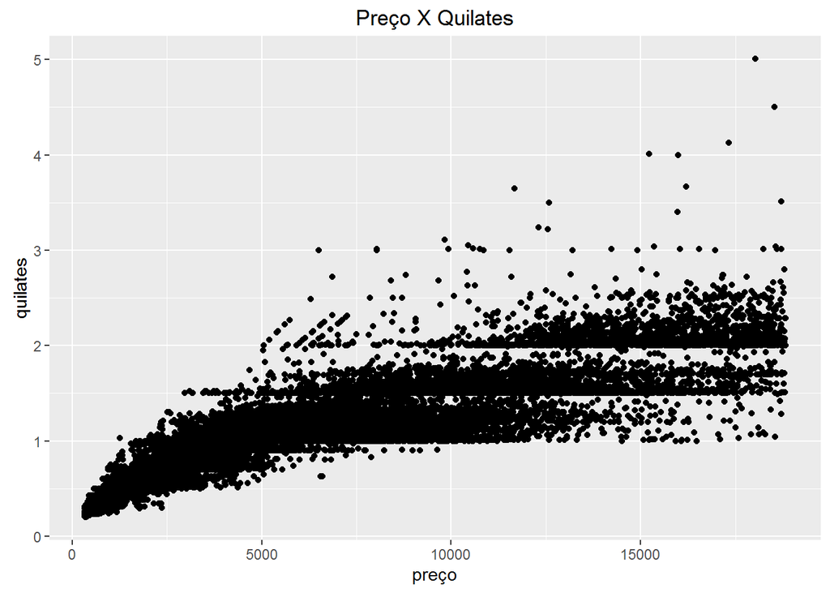

```r
ggplot(data = diamonds, aes(x = price, y = carat)) +
  geom_point() + xlab("preço") + ylab("quilates") +labs(title = "Preço X Quilates")
```

## 3. Utilize a facets para fazer gráficos de dispersão do preço pela variável quilate

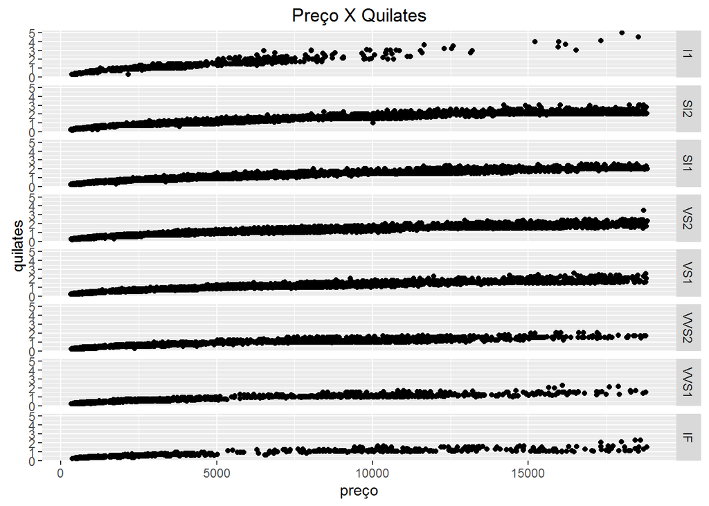

```r
ggplot(data = diamonds, aes(x = price, y = carat)) +
  geom_point() + xlab("preço") + ylab("quilates") +labs(title = "Preço X Quilates") +
  facet_grid(clarity ~ .)
```

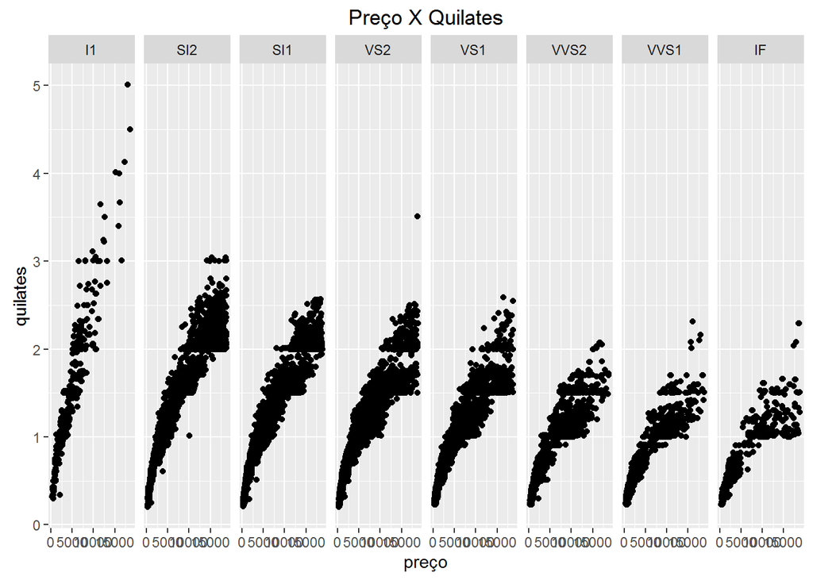

```r
ggplot(data = diamonds, aes(x = price, y = carat)) +
  geom_point() + xlab("preço") + ylab("quilates") +labs(title = "Preço X Quilates") +
  facet_grid(. ~ clarity)
```

## 4. Quais são os aspectos estéticos (aesthetics) exigidos (obrigatórios) da função geom_histogram()?

## 5. Faça um histograma da variável preço. Modifique a cor das barras de forma que elas

## não pareçam grudadas umas nas outras.

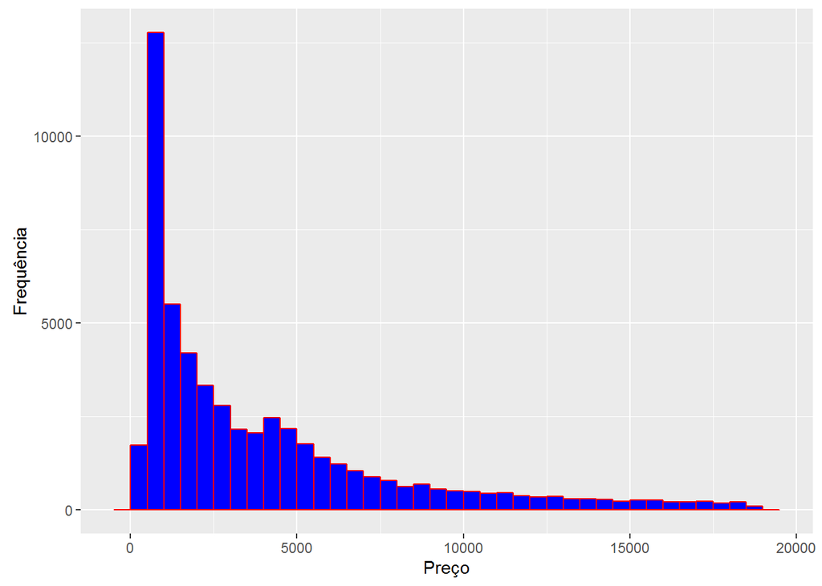

```r
  ggplot(data = diamonds, aes(x = price)) +
  geom_histogram(fill=I("blue"),binwidth = 500,col=I("red")) +
  xlab("Preço") +
  ylab("Frequência")
```

## 6. Utilize a função geom_density() para adicionar ao gráfico anterior uma estimativa

## suavizada da densidade.

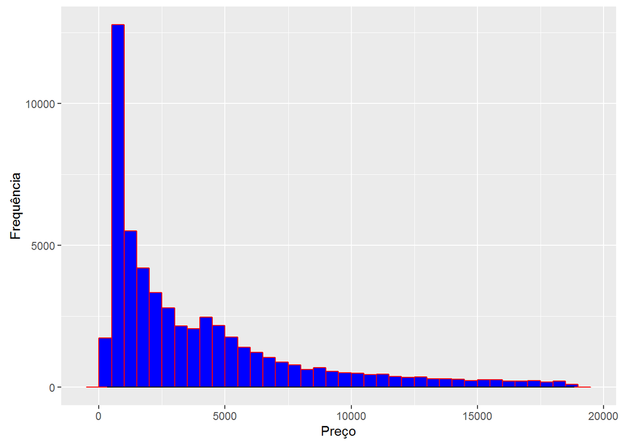

```r
ggplot(data = diamonds, aes(x = price)) +
  geom_histogram(fill=I("blue"),binwidth = 500,col=I("red")) +
  xlab("Preço") +
  ylab("Frequência") +
  geom_density(data=diamonds, aes(x=price, group=carat),alpha=0.5, adjust=2) +
  xlab("Preço") +
  ylab("Frequência")
```

## 7. Quais são os aspectos estéticos (aesthetics) exigidos (obrigatórios) da função geom_boxplot()?

## 8. Faça boxplots da variável preço coloridos de acordo com a variável corte (cut).

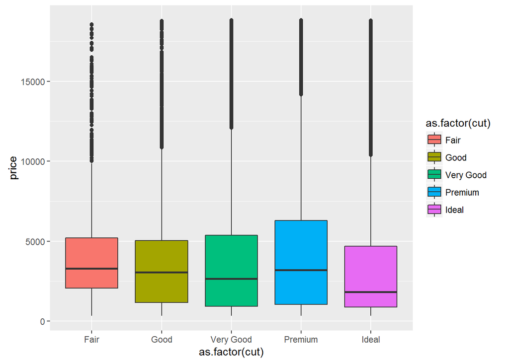

```r
ggplot(data = diamonds, aes(x = as.factor(cut), y = price, fill = as.factor(cut))) + geom_boxplot()
```

## 9. Substitua as cores padrões e remova a legenda do gráfico anterior.

## (Dica: use a função scale_color_manual)

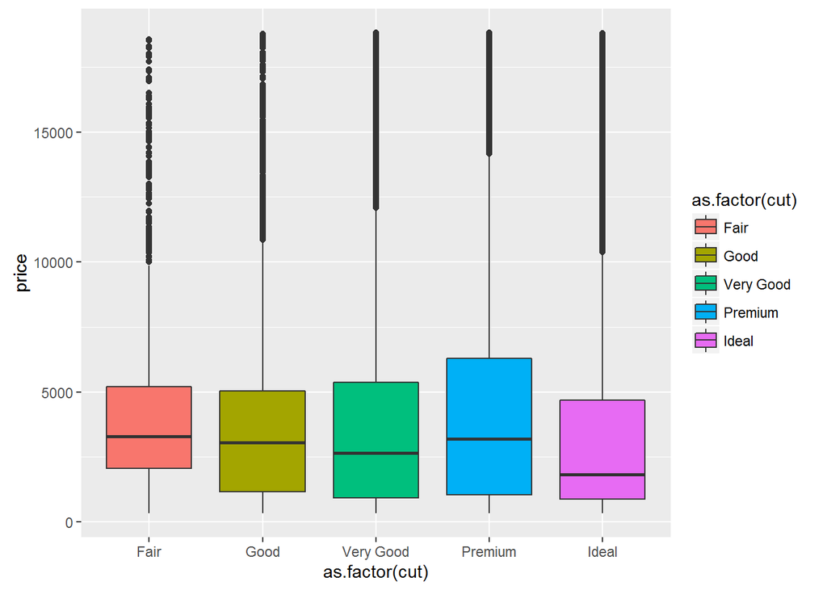

```r
ggplot(data = diamonds, aes(x = as.factor(cut), y = price, fill = as.factor(cut))) + geom_boxplot()
```

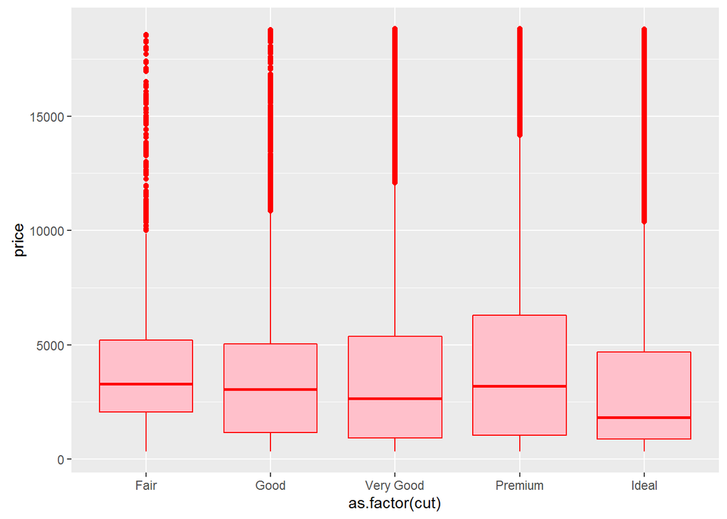

```r
ggplot(data = diamonds, aes(x = as.factor(cut), y = price)) +
  geom_boxplot(color = "red", fill = "pink")
```

```r
?geom_bar
```

## 10. Quais são os aspectos estéticos (aesthetics) exigidos (obrigatórios) da função geom_bar()?

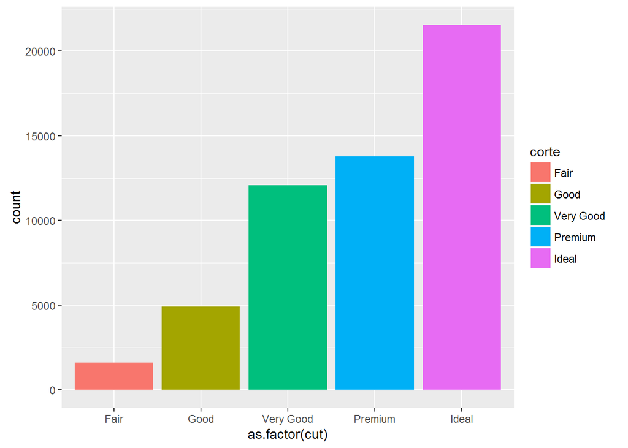

```r
ggplot(data = diamonds, aes(x = as.factor(cut), fill = as.factor(cut))) +
  geom_bar() +
  labs(fill = "corte")
```

## um modelo de regressão

```r
coef(lm(price ~ carat , data = diamonds))
```

```
## (Intercept)       carat
##   -2256.361    7756.426
```

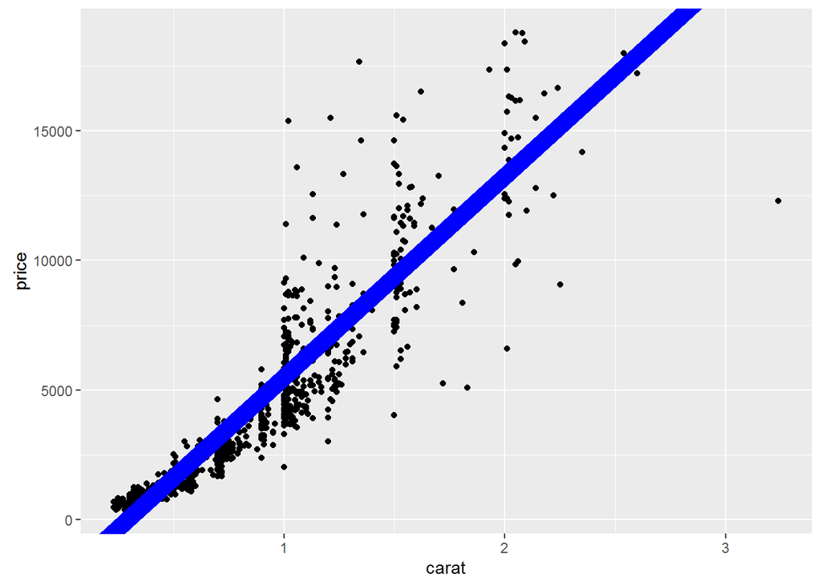

```r
ggplot(data = diamonds %>% sample_n(1000), aes(x = carat, y = price)) +
  geom_point() +
  geom_abline(intercept = -2256.361, slope = 7756.426, color = "blue", size = 5)
```

## suavizer as variaveis por um modelo de regressão

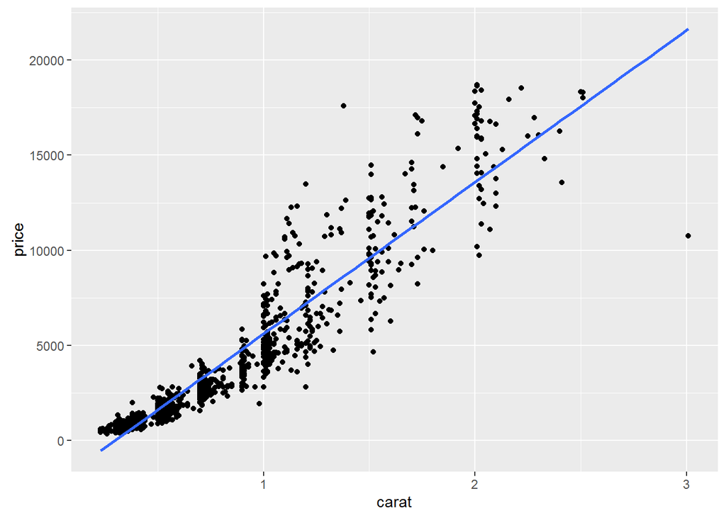

```r
ggplot(data = diamonds %>% sample_n(1000), aes(x = carat, y = price)) +
  geom_point() +
  geom_smooth(method = "lm" , se= F)
```

```r
geom_abline(intercept = -2256.361, slope = 7756.426, color = "blue", size = 5)
```

```
## mapping: intercept = intercept, slope = slope
## geom_abline: na.rm = FALSE
## stat_identity: na.rm = FALSE
## position_identity
```

## suavizer as variaveis por um modelo de regressão

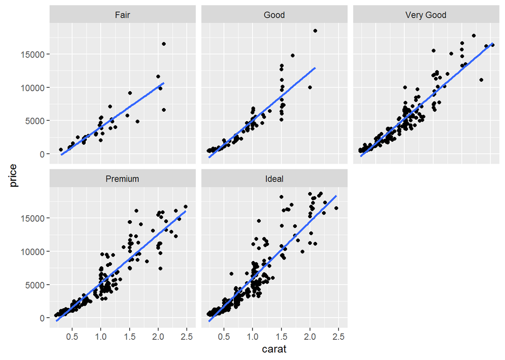

```r
ggplot(data = diamonds %>% sample_n(1000), aes(x = carat, y = price)) +
  geom_point() +
  geom_smooth(se= F, method = "lm") + facet_wrap(~cut)
```

```r
geom_abline(intercept = -2256.361, slope = 7756.426, color = "red", size = 5)
```

```
## mapping: intercept = intercept, slope = slope
## geom_abline: na.rm = FALSE
## stat_identity: na.rm = FALSE
## position_identity
```